# R Notebook

## LM22 signature matrix

- select genes that appear both in the LM22 signature matrix and the SF data
- in those genes, further select genes that have expression in a relatively large amount of cells

```r
CBST_LM22 = read.table("../../_reference/LM22.txt", sep = "\t",
                       header = TRUE, as.is = TRUE)
dim(CBST_LM22)
```

```
## [1] 547  23
```

```r
CBST_LM22[1:2,]
```

|  | Gene.symbol | B.cells.naive | B.cells.memory | Plasma.cells | T.cells.CD8 | T.cells.CD4.naive | T.cells.CD4.memory.resting | T.cells.CD4.memory.activated | T.cells.follicular.helper | T.cells.regulatory..Tregs. | T.cells.gamma.delta | NK.cells.resting | NK.cells.activated | Monocytes | Macrophages.M0 | Macrophages.M1 | Macrophages.M2 | Dendritic.cells.resting | Dendritic.cells.activated | Mast.cells.resting | Mast.cells.activated | Eosinophils | Neutrophils |
| --- | --- | --- | --- | --- | --- | --- | --- | --- | --- | --- | --- | --- | --- | --- | --- | --- | --- | --- | --- | --- | --- | --- | --- |
| 1 | ABCB4 | 555.71345 | 10.74423 | 7.225819 | 4.31128 | 4.60586 | 7.406442 | 8.043976 | 6.469993 | 7.833082 | 9.312295 | 13.68284 | 4.556713 | 6.202496 | 7.95136 | 27.55771 | 121.43228 | 114.6367 | 4.872184 | 4.727985 | 34.11366 | 15.03053 | 14.90689 |
| 2 | ABCB9 | 15.60354 | 22.09479 | 653.392328 | 24.22372 | 35.67151 | 30.048192 | 38.455423 | 17.604795 | 46.073657 | 19.715722 | 21.86372 | 16.396143 | 20.309426 | 56.25189 | 29.38088 | 40.39026 | 123.9933 | 23.384603 | 53.466757 | 23.61575 | 29.78644 | 33.67915 |

```r
# 538 out of 547
CBST.SFgenes = CBST_LM22$Gene.symbol[CBST_LM22$Gene.symbol %in% gene.names]
length(CBST.SFgenes)
```

```
## [1] 538
```

```r
# 323 out of 538
CBST.HE.genes = intersect(CBST.SFgenes, high.express.genes.all)
length(CBST.HE.genes)
```

```
## [1] 323
```

```r
# 323 x 23
CBST_LM22_SF_HEgenes = CBST_LM22[match(CBST.HE.genes, CBST_LM22$Gene.symbol),]

dim(CBST_LM22_SF_HEgenes)
```

```
## [1] 323  23
```

```r
CBST_LM22_SF_HEgenes[1:2,]
```

|  | Gene.symbol | B.cells.naive | B.cells.memory | Plasma.cells | T.cells.CD8 | T.cells.CD4.naive | T.cells.CD4.memory.resting | T.cells.CD4.memory.activated | T.cells.follicular.helper | T.cells.regulatory..Tregs. | T.cells.gamma.delta | NK.cells.resting | NK.cells.activated | Monocytes | Macrophages.M0 | Macrophages.M1 | Macrophages.M2 | Dendritic.cells.resting | Dendritic.cells.activated | Mast.cells.resting | Mast.cells.activated | Eosinophils | Neutrophils |
| --- | --- | --- | --- | --- | --- | --- | --- | --- | --- | --- | --- | --- | --- | --- | --- | --- | --- | --- | --- | --- | --- | --- | --- |
| 3 | ACAP1 | 215.3060 | 321.621 | 38.61687 | 1055.6134 | 1790.0972 | 922.1527 | 340.8834 | 1107.7983 | 1995.483 | 280.0757 | 512.6369 | 387.5817 | 190.8790 | 48.97222 | 30.97425 | 23.05515 | 61.38655 | 26.41292 | 104.2002 | 73.60793 | 696.4428 | 596.0260 |
| 5 | ACP5 | 605.8974 | 1935.201 | 1120.10468 | 306.3125 | 744.6566 | 557.8198 | 248.5469 | 711.9497 | 958.916 | 493.9691 | 340.8201 | 239.2771 | 512.9314 | 13644.17230 | 1062.47591 | 7633.96018 | 13825.05363 | 3989.86517 | 263.4979 | 323.38128 | 860.5634 | 307.1428 |

# Compare the correlation of cell types

## Correlation matrix for our 11 cell types

### using mean expression of filtered genes shared between SF data and LM22 matrix

```r
table(rownames(clustered_tpm_HEgenes) == high.express.genes.all)
```

```
##
##  TRUE
## 12705
```

```r
match1 = match(CBST.HE.genes, high.express.genes.all)
HEgenes_CBST_tpm = as.data.table(t(clustered_tpm_HEgenes[match1,]))

rownames(HEgenes_CBST_tpm) = clustered_cells
colnames(HEgenes_CBST_tpm) = CBST.HE.genes
dim(HEgenes_CBST_tpm)
```

```
## [1] 14544   323
```

```r
HEgenes_CBST_tpm[1:5,1:5]
```

| ACAP1 | ACP5 | ADAM28 | ADRB2 | AIF1 |
| --- | --- | --- | --- | --- |
| 0.00 | 0.00 | 0 | 0 | 0 |
| 0.00 | 9.71 | 0 | 0 | 0 |
| 10.09 | 9.45 | 0 | 0 | 0 |
| 8.03 | 8.76 | 0 | 0 | 0 |
| 10.26 | 0.00 | 0 | 0 | 0 |

```r
HEgenes_CBST_tpm$grouping = factor(cell_type$type[match(clustered_cells, cell_type$cell)])
table(HEgenes_CBST_tpm$grouping)
```

```
##
##               B_cells           CD4T_memory                CD8T_B
##                  1427                  1099                  2322
##                CD8T_G       Dendritic_cells Monocytes_Macrophages
##                  3036                   281                  1330
##                   NK1                   NK2                   NK3
##                   456                  1961                  1096
##          Plasma_cells                 Tregs
##                   284                  1252
```

```r
cmean = HEgenes_CBST_tpm[, lapply(.SD, mean),   by = grouping]
cmed  = HEgenes_CBST_tpm[, lapply(.SD, median), by = grouping]
csd   = HEgenes_CBST_tpm[, lapply(.SD, sd),     by = grouping]

dim(cmean)
```

```
## [1]  11 324
```

```r
cmean[1:2,1:5]
```

| grouping | ACAP1 | ACP5 | ADAM28 | ADRB2 |
| --- | --- | --- | --- | --- |
| NK2 | 4.099317 | 0.9279398 | 0.2410148 | 1.3429067 |
| Tregs | 4.976054 | 2.7917732 | 0.1379473 | 0.1113099 |

```r
dim(cmed)
```

```
## [1]  11 324
```

```r
cmed[1:2,1:5]
```

| grouping | ACAP1 | ACP5 | ADAM28 | ADRB2 |
| --- | --- | --- | --- | --- |
| NK2 | 0.0 | 0 | 0 | 0 |
| Tregs | 7.4 | 0 | 0 | 0 |

```r
dim(csd)
```

```
## [1]  11 324
```

```r
csd[1:2,1:5]
```

| grouping | ACAP1 | ACP5 | ADAM28 | ADRB2 |
| --- | --- | --- | --- | --- |
| NK2 | 4.433886 | 2.720048 | 1.3203442 | 3.1720721 |
| Tregs | 4.255101 | 4.086167 | 0.9495122 | 0.9476409 |

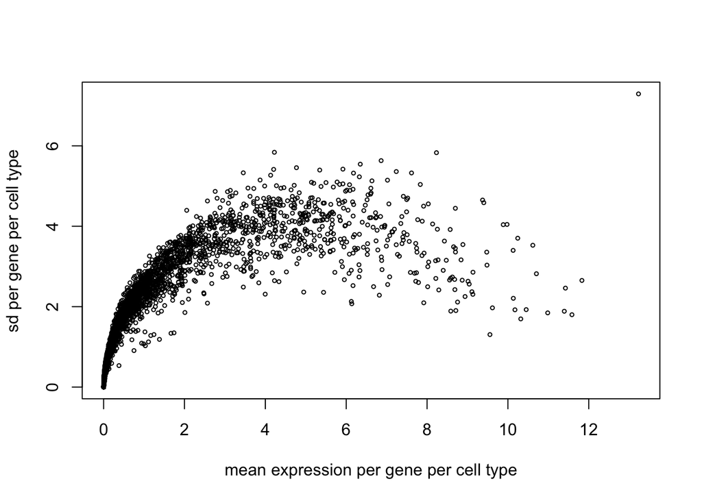

```r
plot(as.numeric(unlist(cmean[,-1])), as.numeric(unlist(csd[,-1])),
     xlab="mean expression per gene per cell type",
     ylab="sd per gene per cell type", cex=0.5)
```

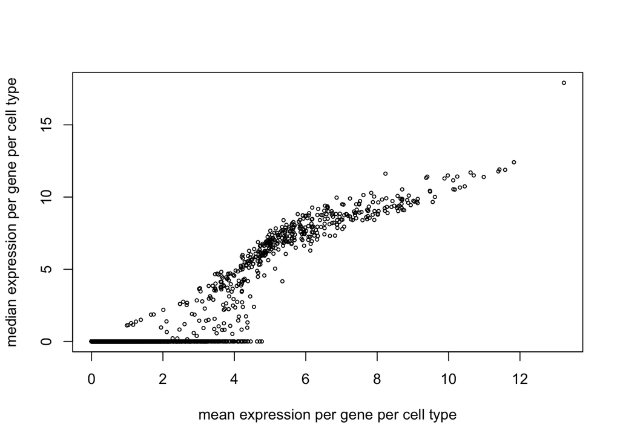

```r
plot(as.numeric(unlist(cmean[,-1])), as.numeric(unlist(cmed[,-1])),
     xlab="mean expression per gene per cell type",
     ylab="median expression per gene per cell type", cex=0.5)
```

```r
HEgene_CBST_expression = HEgenes_CBST_tpm[, lapply(.SD, mean), by = grouping]
HEgene_CBST_expression = HEgene_CBST_expression[order(HEgene_CBST_expression$grouping),]
dim(HEgene_CBST_expression)
```

```
## [1]  11 324
```

```r
HEgene_CBST_expression[,1:6]
```

| grouping | ACAP1 | ACP5 | ADAM28 | ADRB2 | AIF1 |
| --- | --- | --- | --- | --- | --- |
| B_cells | 3.935004 | 2.5622355 | 5.96788367 | 0.5603854 | 0.11435179 |
| CD4T_memory | 4.202520 | 0.7848772 | 0.05037307 | 0.3710919 | 0.28582348 |
| CD8T_B | 5.626034 | 3.1335960 | 0.28737726 | 0.4937941 | 0.63442722 |
| CD8T_G | 4.367760 | 0.9722266 | 0.18944005 | 1.0855962 | 0.19091897 |
| Dendritic_cells | 3.436441 | 1.7495374 | 0.64576512 | 0.6890391 | 1.94761566 |
| Monocytes_Macrophages | 1.331346 | 3.7605338 | 2.12909774 | 1.0839098 | 8.93978947 |
| NK1 | 5.145197 | 2.5918421 | 0.29322368 | 0.4564035 | 0.98817982 |
| NK2 | 4.099317 | 0.9279398 | 0.24101479 | 1.3429067 | 0.11785824 |
| NK3 | 5.365748 | 3.0093704 | 0.46216241 | 0.6136770 | 0.49431569 |
| Plasma_cells | 1.601268 | 0.9891901 | 1.93566901 | 0.5171831 | 0.05735915 |

[output cut: 1 more lines]

```r
HEgene_CBST_compare_expression = as.data.frame(t(HEgene_CBST_expression[,-1]))
colnames(HEgene_CBST_compare_expression) = HEgene_CBST_expression$grouping
head(HEgene_CBST_compare_expression)
```

|  | B_cells | CD4T_memory | CD8T_B | CD8T_G | Dendritic_cells | Monocytes_Macrophages | NK1 | NK2 | NK3 | Plasma_cells | Tregs |
| --- | --- | --- | --- | --- | --- | --- | --- | --- | --- | --- | --- |
| ACAP1 | 3.9350035 | 4.20252047 | 5.6260336 | 4.3677602 | 3.43644128 | 1.3313459 | 5.1451974 | 4.0993167 | 5.3657482 | 1.60126761 | 4.97605431 |
| ACP5 | 2.5622355 | 0.78487716 | 3.1335960 | 0.9722266 | 1.74953737 | 3.7605338 | 2.5918421 | 0.9279398 | 3.0093704 | 0.98919014 | 2.79177316 |
| ADAM28 | 5.9678837 | 0.05037307 | 0.2873773 | 0.1894401 | 0.64576512 | 2.1290977 | 0.2932237 | 0.2410148 | 0.4621624 | 1.93566901 | 0.13794728 |
| ADRB2 | 0.5603854 | 0.37109190 | 0.4937941 | 1.0855962 | 0.68903915 | 1.0839098 | 0.4564035 | 1.3429067 | 0.6136770 | 0.51718310 | 0.11130990 |
| AIF1 | 0.1143518 | 0.28582348 | 0.6344272 | 0.1909190 | 1.94761566 | 8.9397895 | 0.9881798 | 0.1178582 | 0.4943157 | 0.05735915 | 0.08802716 |
| AIM2 | 1.1861738 | 0.25397634 | 0.7434453 | 0.4483696 | 0.02597865 | 0.6255489 | 1.0510088 | 0.3183937 | 0.4659763 | 0.87186620 | 0.73174121 |

```r
rm(HEgene_CBST_expression)
rm(HEgenes_CBST_tpm)
```

The patterns of the correlation roughly match our expectation:

- Plasma cells, Monocytes/Macrophages, Dendritic cells and B cells do no have major correlation with other cell types, matches the clustering result that these 4 cell types form most distinct clusters
- The 3 NK cell clusters are closely related with each other
- CD8 cells, NK cells, and CD4 T cells are closely related

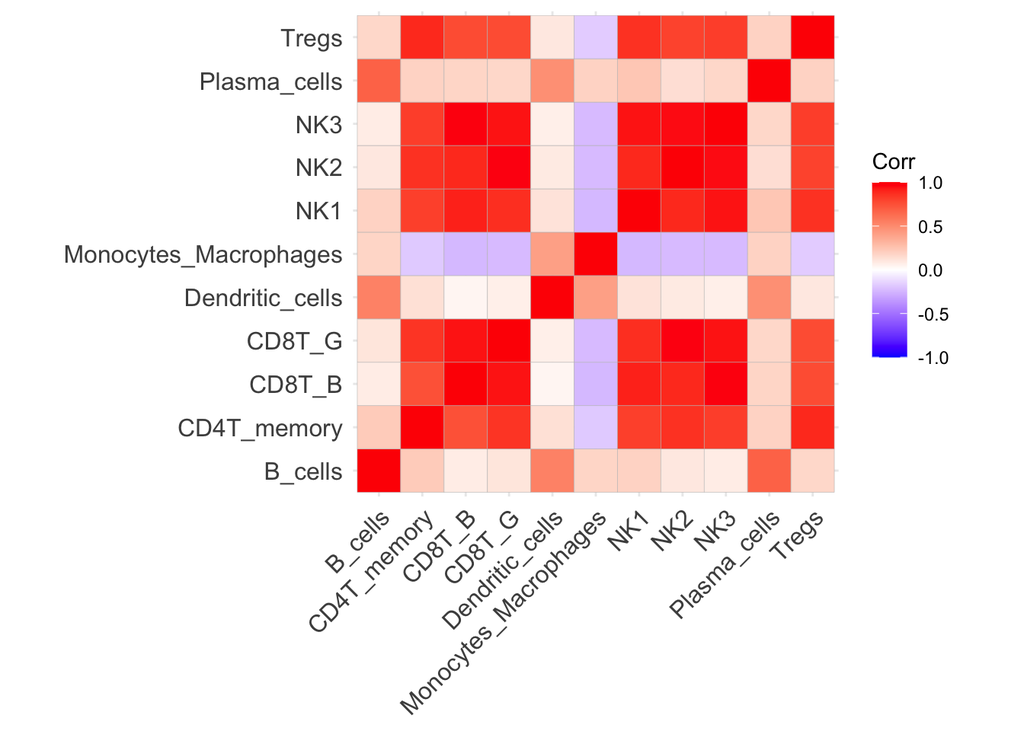

```r
cormat_HE.CBSTgenes_11type = cor(HEgene_CBST_compare_expression, method = "spearman")
ggcorrplot(cormat_HE.CBSTgenes_11type)
```

### using mean expression for filtered genes shared between SF data and LM22 matrix, over the cells with fewer zero gene expression

```r
match1 = match(CBST.HE.genes, high.express.genes.all)
HEgenes_CBST_few0_tpm = as.data.table(t(clustered_tpm_HEgenes[match1, ..fewzero_cells]))
rownames(HEgenes_CBST_few0_tpm) = fewzero_cells
colnames(HEgenes_CBST_few0_tpm) = CBST.HE.genes

HEgenes_CBST_few0_tpm[1:5,1:5]
```

| ACAP1 | ACP5 | ADAM28 | ADRB2 | AIF1 |
| --- | --- | --- | --- | --- |
| 0.00 | 0.00 | 0.00 | 0 | 0 |
| 8.36 | 8.10 | 0.00 | 0 | 0 |
| 8.22 | 9.02 | 8.57 | 0 | 0 |
| 7.74 | 0.00 | 2.82 | 0 | 0 |
| 8.73 | 0.00 | 8.34 | 0 | 0 |

```r
mat1 = match(fewzero_cells, cell_type$cell)
HEgenes_CBST_few0_tpm$grouping = factor(cell_type$type[mat1])
table(HEgenes_CBST_few0_tpm$grouping)
```

```
##
##               B_cells           CD4T_memory                CD8T_B
##                  1068                   821                  1741
##                CD8T_G       Dendritic_cells Monocytes_Macrophages
##                  2277                   210                   996
##                   NK1                   NK2                   NK3
##                   341                  1470                   822
##          Plasma_cells                 Tregs
##                   213                   939
```

```r
# 11 x 324
HEgene_CBST_few0_expression = HEgenes_CBST_few0_tpm[, lapply(.SD, mean), by = grouping]
HEgene_CBST_few0_expression[,1:6]
```

| grouping | ACAP1 | ACP5 | ADAM28 | ADRB2 | AIF1 |
| --- | --- | --- | --- | --- | --- |
| B_cells | 4.227996 | 2.7645693 | 5.93699438 | 0.5284831 | 0.14382022 |
| CD4T_memory | 4.342887 | 0.8473691 | 0.05724726 | 0.3898417 | 0.33255786 |
| CD8T_B | 5.677191 | 3.2413900 | 0.25995979 | 0.4901149 | 0.75183802 |
| CD8T_G | 4.456680 | 1.0618182 | 0.19836188 | 1.1932938 | 0.21800176 |
| Dendritic_cells | 3.865476 | 2.1077619 | 0.71476190 | 0.6695238 | 2.19209524 |
| Monocytes_Macrophages | 1.406797 | 4.3213655 | 2.37260040 | 1.2067972 | 9.22597390 |
| NK1 | 5.499648 | 2.7685630 | 0.27853372 | 0.3557771 | 1.21554252 |
| NK2 | 4.292531 | 1.0102653 | 0.23923129 | 1.4077279 | 0.14075510 |
| NK3 | 5.671277 | 3.0373966 | 0.47030414 | 0.6644039 | 0.58903893 |
| Plasma_cells | 1.519061 | 1.1080282 | 1.93079812 | 0.5718310 | 0.04784038 |

[output cut: 1 more lines]

```r
HEgene_CBST_few0_compare_expression = as.data.frame(t(HEgene_CBST_few0_expression[,-1]))
colnames(HEgene_CBST_few0_compare_expression) = HEgene_CBST_few0_expression$grouping
head(HEgene_CBST_few0_compare_expression)
```

|  | B_cells | CD4T_memory | CD8T_B | CD8T_G | Dendritic_cells | Monocytes_Macrophages | NK1 | NK2 | NK3 | Plasma_cells | Tregs |
| --- | --- | --- | --- | --- | --- | --- | --- | --- | --- | --- | --- |
| ACAP1 | 4.2279963 | 4.34288672 | 5.6771913 | 4.4566798 | 3.86547619 | 1.4067972 | 5.4996481 | 4.2925306 | 5.6712774 | 1.51906103 | 5.3015974 |
| ACP5 | 2.7645693 | 0.84736906 | 3.2413900 | 1.0618182 | 2.10776190 | 4.3213655 | 2.7685630 | 1.0102653 | 3.0373966 | 1.10802817 | 2.9171991 |
| ADAM28 | 5.9369944 | 0.05724726 | 0.2599598 | 0.1983619 | 0.71476190 | 2.3726004 | 0.2785337 | 0.2392313 | 0.4703041 | 1.93079812 | 0.1103940 |
| ADRB2 | 0.5284831 | 0.38984166 | 0.4901149 | 1.1932938 | 0.66952381 | 1.2067972 | 0.3557771 | 1.4077279 | 0.6644039 | 0.57183099 | 0.1177849 |
| AIF1 | 0.1438202 | 0.33255786 | 0.7518380 | 0.2180018 | 2.19209524 | 9.2259739 | 1.2155425 | 0.1407551 | 0.5890389 | 0.04784038 | 0.1074973 |
| AIM2 | 1.2613390 | 0.27571255 | 0.8605859 | 0.4667721 | 0.01742857 | 0.7762249 | 1.0382111 | 0.3098571 | 0.5367640 | 0.98774648 | 0.7899148 |

```r
rm(HEgene_CBST_few0_expression)
rm(HEgenes_CBST_few0_tpm)
```

The result using cells with fewer zero expression genes is not very different from the result using all cells.

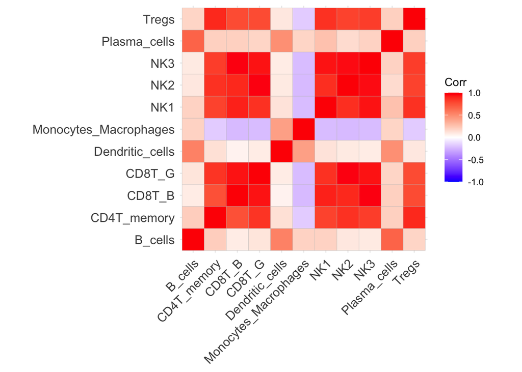

```r
cormat_HE.CBST.few0genes_11type = cor(HEgene_CBST_few0_compare_expression,
                                      method = "spearman")
ggcorrplot(cormat_HE.CBST.few0genes_11type)
```

```r
table(colnames(HEgene_CBST_few0_compare_expression) ==
        colnames(HEgene_CBST_compare_expression))
```

```
##
## TRUE
##   11
```

```r
cor_2signatures = cor(HEgene_CBST_compare_expression,
                      HEgene_CBST_few0_compare_expression,
                      method = "spearman")
summary(diag(cor_2signatures))
```

```
##    Min. 1st Qu.  Median    Mean 3rd Qu.    Max.
##  0.9904  0.9978  0.9984  0.9973  0.9988  0.9993
```

## Correlations between our 11 cell types and the cell types in the LM22 matrix

### using mean expression of filtered genes shared between SF data and LM22 matrix

```r
cormat_LM22_11type = cor(CBST_LM22_SF_HEgenes[,-1],
                         HEgene_CBST_compare_expression,
                         method = "spearman")
dim(cormat_LM22_11type)
```

```
## [1] 22 11
```

```r
cormat_LM22_11type[1:2,1:3]
```

```
##                  B_cells CD4T_memory     CD8T_B
## B.cells.naive  0.5723921  0.07742753 0.02227276
## B.cells.memory 0.6461780  0.11147505 0.06188746
```

```r
range(c(cormat_LM22_11type))
```

```
## [1] -0.3009710  0.7733207
```

The correlations between our 11 cell types and the cell types in the LM22 matrix.

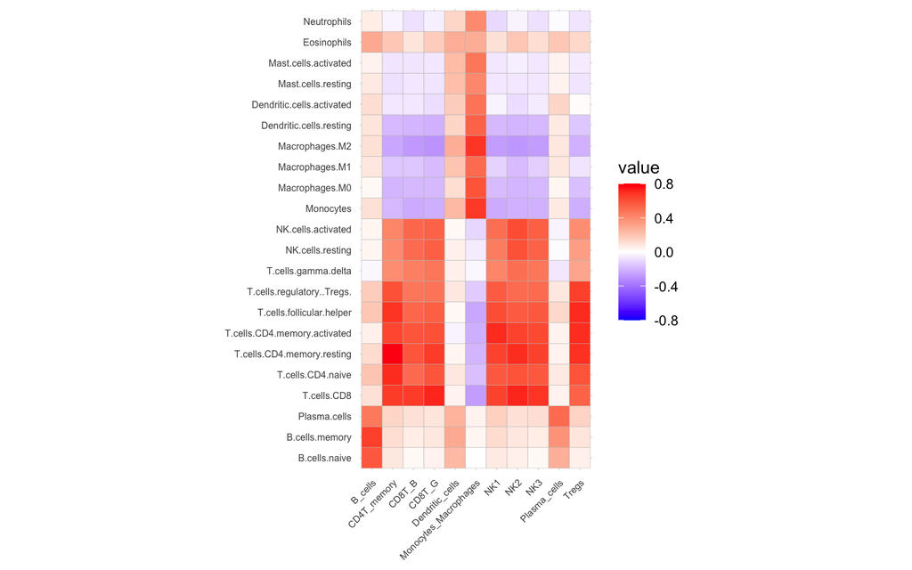

```r
p = ggcorrplot(t(cormat_LM22_11type), tl.cex = 6)
p + scale_fill_gradient2(limit = c(-0.8,0.8), low = "blue", high =  "red",
                         mid = "white", midpoint = 0)
```

### using mean expression for filtered genes shared between SF data and LM22 matrix over cells with fewer zero gene expression

```r
cormat_LM22_11type_few0 = cor(CBST_LM22_SF_HEgenes[,-1],
                              HEgene_CBST_few0_compare_expression,
                         method = "spearman")
dim(cormat_LM22_11type_few0)
```

```
## [1] 22 11
```

```r
cormat_LM22_11type_few0[1:2,1:3]
```

```
##                  B_cells CD4T_memory     CD8T_B
## B.cells.naive  0.5709810  0.07550688 0.02266216
## B.cells.memory 0.6448605  0.11074219 0.06282740
```

```r
range(c(cormat_LM22_11type_few0))
```

```
## [1] -0.3025097  0.7716825
```

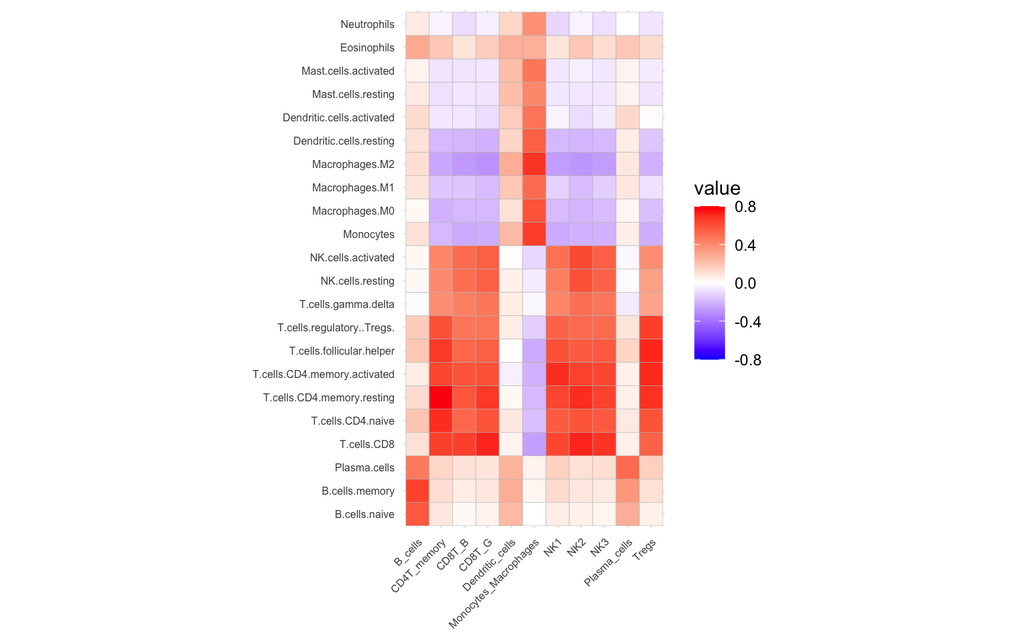

```r
p = ggcorrplot(t(cormat_LM22_11type_few0), tl.cex = 6)
p + scale_fill_gradient2(limit = c(-0.8,0.8), low = "blue", high =  "red",
                         mid = "white", midpoint = 0)
```

## Compare the scatterplot of gene expressions between LM22 cell types and our cell types

### B cells and B cells

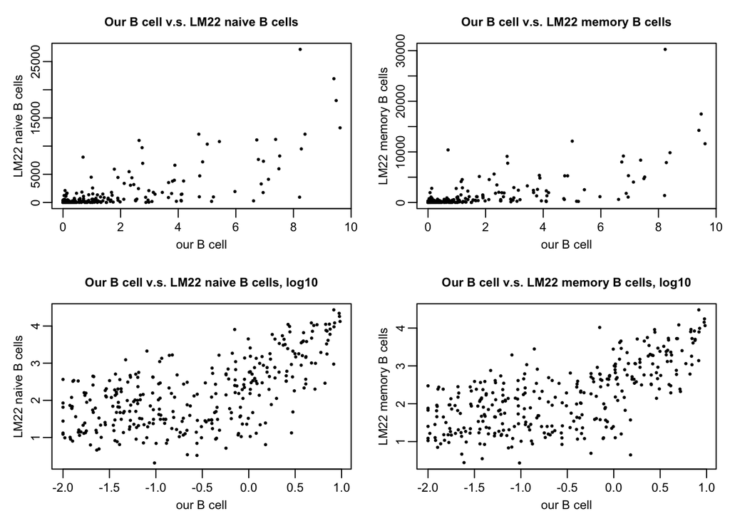

```r
par(mar=c(3,3,2.5,0.8), mgp=c(1.5,0.5,0), cex.axis=0.85, cex.lab=0.85, cex.main=0.85)
layout(matrix(c(1,2,3,4),nrow=2,ncol = 2,byrow = TRUE))

plot(as.numeric(HEgene_CBST_compare_expression$`B_cells`),
               as.numeric(CBST_LM22_SF_HEgenes$B.cells.naive),
               main = "Our B cell v.s. LM22 naive B cells",
               xlab = "our B cell", ylab = "LM22 naive B cells",
               pch=20, cex = 0.5)

plot(as.numeric(HEgene_CBST_compare_expression$`B_cells`),
               as.numeric(CBST_LM22_SF_HEgenes$B.cells.memory),
               main = "Our B cell v.s. LM22 memory B cells",
               xlab = "our B cell", ylab = "LM22 memory B cells",
               pch=20, cex = 0.5)

plot(log10(as.numeric(HEgene_CBST_compare_expression$`B_cells`) + 0.01),
               log10(as.numeric(CBST_LM22_SF_HEgenes$B.cells.naive) + 0.01),
               main = "Our B cell v.s. LM22 naive B cells, log10",
               xlab = "our B cell", ylab = "LM22 naive B cells",
               pch=20, cex = 0.5)

plot(log10(as.numeric(HEgene_CBST_compare_expression$`B_cells`) + 0.01),
               log10(as.numeric(CBST_LM22_SF_HEgenes$B.cells.memory) + 0.01),
               main = "Our B cell v.s. LM22 memory B cells, log10",
               xlab = "our B cell", ylab = "LM22 memory B cells",
               pch=20, cex = 0.5)
```

### CD8 cells and CD8 cells

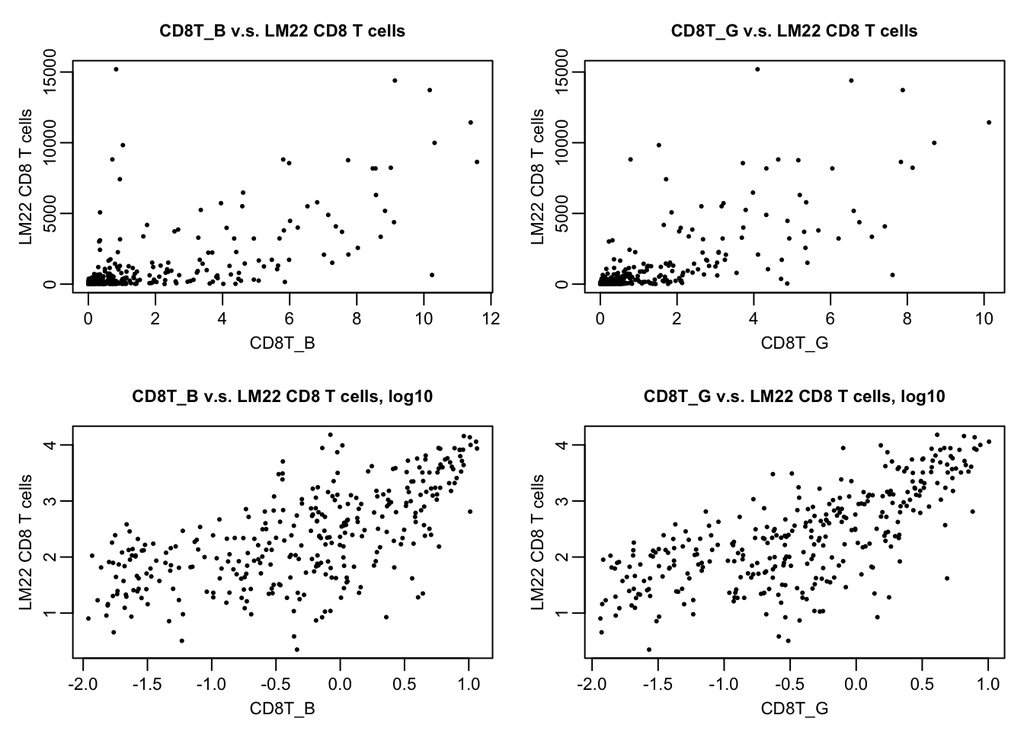

```r
par(mar=c(3,3,2.5,0.8), mgp=c(1.5,0.5,0), cex.axis=0.85, cex.lab=0.85, cex.main=0.85)
layout(matrix(c(1,2,3,4),nrow=2,ncol = 2,byrow = TRUE))


plot(as.numeric(HEgene_CBST_compare_expression$`CD8T_B`),
               as.numeric(CBST_LM22_SF_HEgenes$T.cells.CD8),
               main = "CD8T_B v.s. LM22 CD8 T cells",
               xlab = "CD8T_B", ylab = "LM22 CD8 T cells",
               pch=20, cex = 0.5)

plot(as.numeric(HEgene_CBST_compare_expression$`CD8T_G`),
               as.numeric(CBST_LM22_SF_HEgenes$T.cells.CD8),
               main = "CD8T_G v.s. LM22 CD8 T cells",
               xlab = "CD8T_G", ylab = "LM22 CD8 T cells",
               pch=20, cex = 0.5)

plot(log10(as.numeric(HEgene_CBST_compare_expression$`CD8T_B`) + 0.01),
               log10(as.numeric(CBST_LM22_SF_HEgenes$T.cells.CD8) + 0.01),
               main = "CD8T_B v.s. LM22 CD8 T cells, log10",
               xlab = "CD8T_B", ylab = "LM22 CD8 T cells",
               pch=20, cex = 0.5)

plot(log10(as.numeric(HEgene_CBST_compare_expression$`CD8T_G`) + 0.01),
               log10(as.numeric(CBST_LM22_SF_HEgenes$T.cells.CD8) + 0.01),
               main = "CD8T_G v.s. LM22 CD8 T cells, log10",
               xlab = "CD8T_G", ylab = "LM22 CD8 T cells",
               pch=20, cex = 0.5)
```

```r
gc()
```

```
##             used   (Mb) gc trigger   (Mb) limit (Mb)   max used    (Mb)
## Ncells   1115636   59.6    1911561  102.1         NA    1911561   102.1
## Vcells 277740541 2119.0 1090480630 8319.8      32768 1957518732 14934.7
```